# QTL mapping and analysis with QTLseqR

This notebook aims at analysing csv file containing vcf information (PL, DP, AD) for a F2 population phenotyped and grouped into two bulks : high and low. This follows the Bulk Segregant Analysis (BSA) technique along with whole genome sequencing and QTL-mapping and analysis.

# Preparing data

## Load the packages

```r
library(QTLseqr)
library(ggplot2)
library(dplyr)
library(tidyr)
```

## Get data files

```r
HighBulk <- "MIL2-KAD1_L"
LowBulk <- "MIL2-KAD1_E"
setwd("/Users/gaellebustarret/Projects/Stage_3A/QTL_analysis/Data/VCF_files/variant_calling/")
table_file <- "MIL2-KAD1_ParentCalling_DP_OnlyPolymorphic_NoIndel.table"
csv_file <- "MIL2-KAD1_ParentCalling_DP_OnlyPolymorphic_NoIndel.csv"

## Choose which chromosomes will be included in the analysis (i.e. exclude smaller contigs)
Chroms <- paste0(rep("", 5), 1:5)

## Import SNP data from file
df <- importFromGATK(
  file = table_file,
  highBulk = HighBulk,
  lowBulk = LowBulk,
  chromList = Chroms
)
```

```
Removing the following chromosomes: MT, Pltd
```

# Filtering

## Filter SNPs based on some criteria

```r
df_filt <- filterSNPs(
  SNPset = df,
  refAlleleFreq = 0.20,
  minTotalDepth = 100,
  maxTotalDepth = 400,
  minSampleDepth = 40,
  minGQ = 99
)
```

```
Filtering by reference allele frequency: 0.2 <= REF_FRQ <= 0.8
...Filtered 89343 SNPs
Filtering by total sample read depth: Total DP >= 100
...Filtered 263189 SNPs
Filtering by total sample read depth: Total DP <= 400
...Filtered 306 SNPs
Filtering by per sample read depth: DP >= 40
...Filtered 131094 SNPs
GQ columns not found. Skipping...
Original SNP number: 714726, Filtered: 483932, Remaining: 230794
```

# Analysis

The analysis can be done following two factors. You can either do a G’ prime analysis which focuses on the significance of the difference of allele frequencies between the two bulks or a QTLseq analysis to analyse the origin of the alleles from the two bulks. The specific info about both techniques can be found in the manual for QTLseqR.

## Run G’ analysis

```r
df_filt <- runGprimeAnalysis(SNPset = df_filt,
                             windowSize = 1e6,
                             outlierFilter = "deltaSNP")
```

```
Counting SNPs in each window...
Calculating tricube smoothed delta SNP index...
Calculating G and G' statistics...
Using deltaSNP-index to filter outlier regions with a threshold of 0.1
Estimating the mode of a trimmed G prime set using the 'modeest' package...
Calculating p-values...
```

## Run QTLseq analysis

```r
df_filt <- runQTLseqAnalysis(
      SNPset = df_filt,
      windowSize = 1e6,
      popStruc = "F2",
      bulkSize = 250,
      replications = 10000,
      intervals = c(95, 99)
)
```

```
Counting SNPs in each window...
Calculating tricube smoothed delta SNP index...
Returning the following two sided confidence intervals: 95, 99
Variable 'depth' not defined, using min and max depth from data: 40-193
Assuming bulks selected from F2 population, with 250 individuals per bulk.
The 'bulkSize' argument is of length 1, setting number of individuals in both bulks to: 250
Simulating 10000 SNPs with reads at each depth: 40-193
Keeping SNPs with >= 0.3 SNP-index in both simulated bulks
```

# Plots

## SNP-index

The SNP-index is the allele frequency of the alternate allele compared to total (alternate + reference). 0 = 100% reference allele, 1 = 100% alternate allele, 0.5=50% of each.

### Convert data to long format for ggplot2

```r
df_long <- df_filt %>%
  pivot_longer(cols = starts_with("SNPindex"),
               names_to = "phenotype",
               values_to = "SNP_index") %>%
  mutate(phenotype = ifelse(phenotype == "SNPindex.HIGH", "Late", "Early")) %>%
  mutate(POS_Mb = POS / 1000000)
```

### Create the plot

```r
p <- ggplot(df_long, aes(x = POS_Mb, y = SNP_index, color = phenotype)) +
  geom_smooth(method = "auto") +
  facet_wrap(~ CHROM, scales = "free_x", nrow = 1) +
  scale_color_manual(values = c("Late" = "skyblue", "Early" = "orange")) +
  labs(x = "Position (Mb)", y = "SNP Index", color = "phenotype") +
  theme(legend.position = c(.9, .85))
```

### Add marker positions to the plot

```r
markers <- data.frame(
  CHROM = c("4", "4", "4", "4", "4", "4", "5", "5", "5", "5", "5"),
  POS_Mb = c(0.2702020, 1.1259825, 1.2412465, 5.7254595, 9.0143655, 9.1975435, 3.1764150, 4.2262690, 5.1716235, 5.3453005, 5.8284525),
  name = c("FRI", "LD", "GA1", "CRY1", "ESD4", "PHYD", "FLC", "MAF1", "CO", "FRL1", "TFL2"),
  line_number = 1:11
)
```

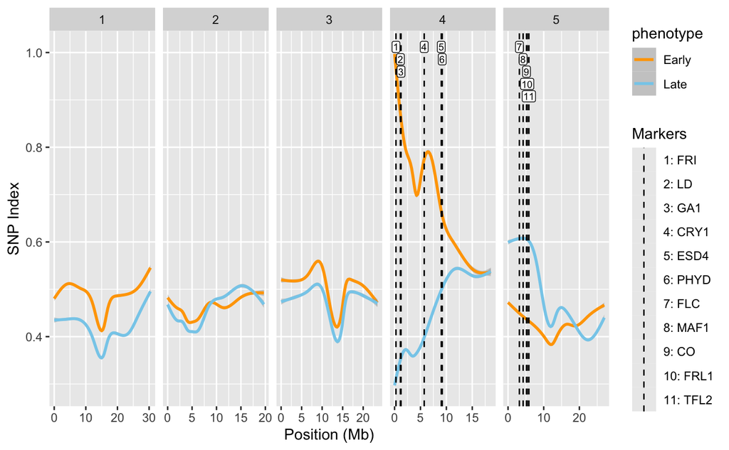

```r
p +
  geom_vline(data = markers, aes(xintercept = POS_Mb, linetype = as.factor(line_number)), color = "black") +
  geom_label(data = markers, aes(x = POS_Mb, y = max(df_long$SNP_index), vjust = c(0, 1.1, 2.2, 0, 0, 1.1, 0, 1.1, 2.2, 3.3, 4.4), label = line_number),
             label.padding = unit(0.1, "lines"), size = 2.5,
             fill = "white", color = "black") +
  scale_linetype_manual(values = rep("dashed", 11), labels = paste(1:11, markers$name, sep = ": "), name = "Markers") +
  guides(linetype = guide_legend(override.aes = list(color = "black"))) +
  facet_wrap(~ CHROM, scales = "free_x", nrow = 1) +
  theme(legend.position = "right")
```

### Extract data

```r
# Build the plot to extract the data

plot_data <- ggplot_build(p)
```

```r
# Extract the smoothed data

smooth_data <- plot_data$data[[1]]
```

```r
# Specify the x value and chromosome you are interested in

x_value <- 8.3573750 # replace with your specific x value
chromosome <- "5" # replace with your specific chromosome value
```

```r
# Filter the smoothed data for the specific x value and chromosome

smoothed_values <- smooth_data %>%
  filter(PANEL == chromosome) %>%
  group_by(group) %>%
  filter(abs(x - x_value) == min(abs(x - x_value))) %>%
  ungroup()
```

```r
# Display the smoothed values

print(smoothed_values)
```

| colour | x | y | ymin | ymax | se | flipped_aes | PANEL | group | fill | linewidth | linetype | weight | alpha |
| --- | --- | --- | --- | --- | --- | --- | --- | --- | --- | --- | --- | --- | --- |
| orange | 8.194993 | 0.4170957 | 0.4146341 | 0.4195574 | 0.001255958 | FALSE | 5 | 1 | grey60 | 1 | 1 | 1 | 0.4 |
| skyblue | 8.194993 | 0.5481081 | 0.5450491 | 0.5511670 | 0.001560724 | FALSE | 5 | 2 | grey60 | 1 | 1 | 1 | 0.4 |